# Paro y Alimentación

Esther Iglesias Gutiérrez y Lucía Segura Benito

2023-01-13

Queremos comprobar si hay algún tipo de relación entre el paro y la mala alimentación.

[Enlace de nuestro repositorio de Github](https://github.com/EstherIglesias/Seminario_Fuentes)

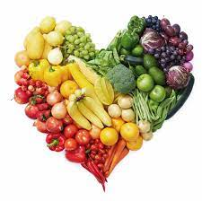

# Introducción

En este trabajo vamos a comprobar si existe una relación entre el paro y una mala alimentación. Para poder realizarlo hemos comenzando buscando información previa en la que hayan sido previamente relacionados. Vemos que sí se ha relacionado el desempleo con un empeoramiento de la dieta y de los cuidados básicos de la salud. También encontramos información entre alimentación y empleo, que son dos conceptos que se retroalimentan. Por tanto, vemos que las personas en paro tienen mayor riesgo de padecer una peor salud (física y mental) y una mayor alimentación basada en ‘comida basura’ y ultraprocesados. Sí hemos encontrado algo de información, pero hemos decido buscar datos de paro y alimentación y crear nuestra propia relación.

# Objetivos

# Métodos

## Carga de paquetes

Vamos a cargar nuestros datos, para poder trabajar con ellos ha sido necesarios cargar con los siguientes paquetes de rstudio:

```r
library(readxl)
library(dplyr)
library(tidyverse)
library("ggplot2")
library(DT)
```

## Carga de datos

Importamos los datos xls. Cargamos nuestros datos de alimentación:

```r
Comidaxsexoencolumnas <- read_excel("input/data/Comidaxsexoencolumnas.xls",
                                    col_types = c("text", "numeric", "numeric", "numeric"))
```

Ahora cargamos los datos de paro:

```r
ParoxsexoEncolumnas <- read_excel("input/data/ParoxsexoEncolumnas.xls",
                                  col_types = c("text", "numeric", "numeric", "numeric"))
```

```r
union <- full_join(x= ParoxsexoEncolumnas, y=Comidaxsexoencolumnas)
```

# Resultados

## Tablas

### Tabla alimentación

Creamos una tabla resumen de los datos de alimentación:

```r
datatable(head(Comidaxsexoencolumnas))
```

|  | ...1 | Ambos sexos | Hombres | Mujeres |
| --- | --- | --- | --- | --- |
| 1 | Fruta fresca (excluye zumos) |  |  |  |
| 2 | A diario | 68.69 | 64.52 | 72.73 |
| 3 | 3 o más veces a la semana pero no a diario | 19.42 | 22 | 16.92 |
| 4 | 1 o 2 veces a la semana | 6.85 | 7.8 | 5.92 |
| 5 | Menos de 1 vez a la semana | 3.23 | 3.55 | 2.92 |
| 6 | Nunca | 1.81 | 2.13 | 1.51 |

### Tabla de paro

Creamos una tabla resumen de los datos de paro:

```r
datatable(head(ParoxsexoEncolumnas))
```

|  | ...1 | Ambos sexos | Hombres | Mujeres |
| --- | --- | --- | --- | --- |
| 1 | Total | 15.53 | 13.87 | 17.43 |
| 2 | De 16 a 19 años | 54.33 | 50.11 | 60.97 |
| 3 | De 20 a 24 años | 35.14 | 34.23 | 36.22 |
| 4 | De 25 a 29 años | 22.91 | 22.16 | 23.69 |
| 5 | De 30 a 34 años | 16.8 | 15.08 | 18.67 |
| 6 | De 35 a 39 años | 14.12 | 11.79 | 16.68 |

### Tabla de union de datos de alimentación y paro

Hacemos una unión de los datos

```r
union <- full_join(x= ParoxsexoEncolumnas, y=Comidaxsexoencolumnas)
```

Creamos una tabla resumen de los datos que hemos obtenido al hacer la unión de los datos:

```r
datatable(head(union))
```

|  | ...1 | Ambos sexos | Hombres | Mujeres |
| --- | --- | --- | --- | --- |
| 1 | Total | 15.53 | 13.87 | 17.43 |
| 2 | De 16 a 19 años | 54.33 | 50.11 | 60.97 |
| 3 | De 20 a 24 años | 35.14 | 34.23 | 36.22 |
| 4 | De 25 a 29 años | 22.91 | 22.16 | 23.69 |
| 5 | De 30 a 34 años | 16.8 | 15.08 | 18.67 |
| 6 | De 35 a 39 años | 14.12 | 11.79 | 16.68 |

## Gráficos

Con los datos obtenidos creamos disintos gráficos para poder llegar a una conclusión.

### Gráfico de la alimentación en relación al sexo

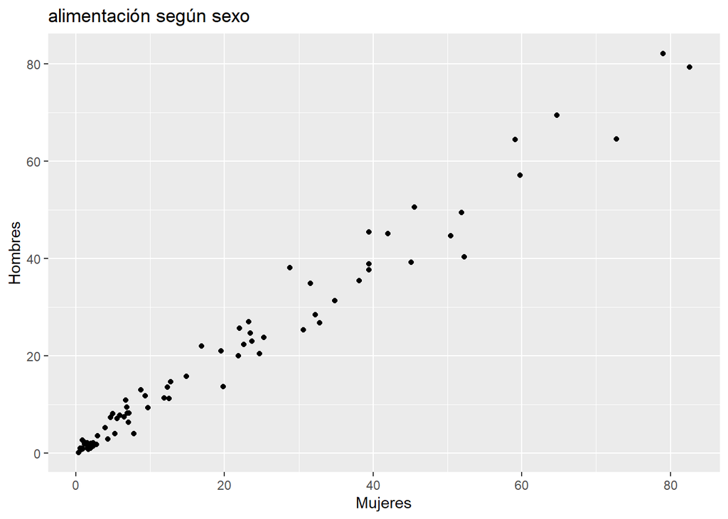

```r
ggplot(data = Comidaxsexoencolumnas) +
  geom_point(mapping = aes( x = Mujeres, y = Hombres)) +
  labs(title = "alimentación según sexo", x = "Mujeres", y = "Hombres")
```

### Gráfico de la alimentación en hombres

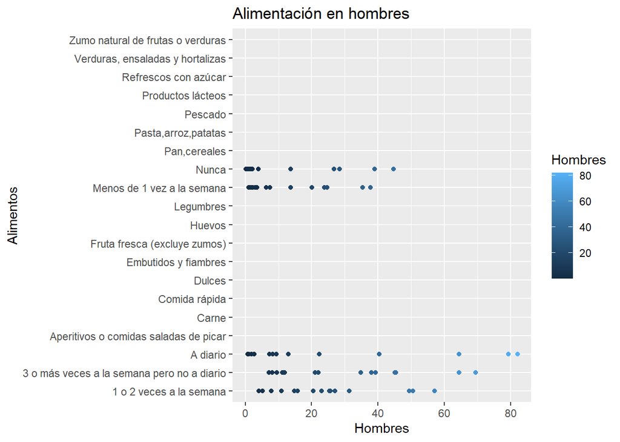

```r
ggplot(data = Comidaxsexoencolumnas) +
  geom_point(mapping = aes( x = Hombres, y= ...1, color= Hombres)) +
  labs(title = "Alimentación en hombres", x="Hombres", y="Alimentos")
```

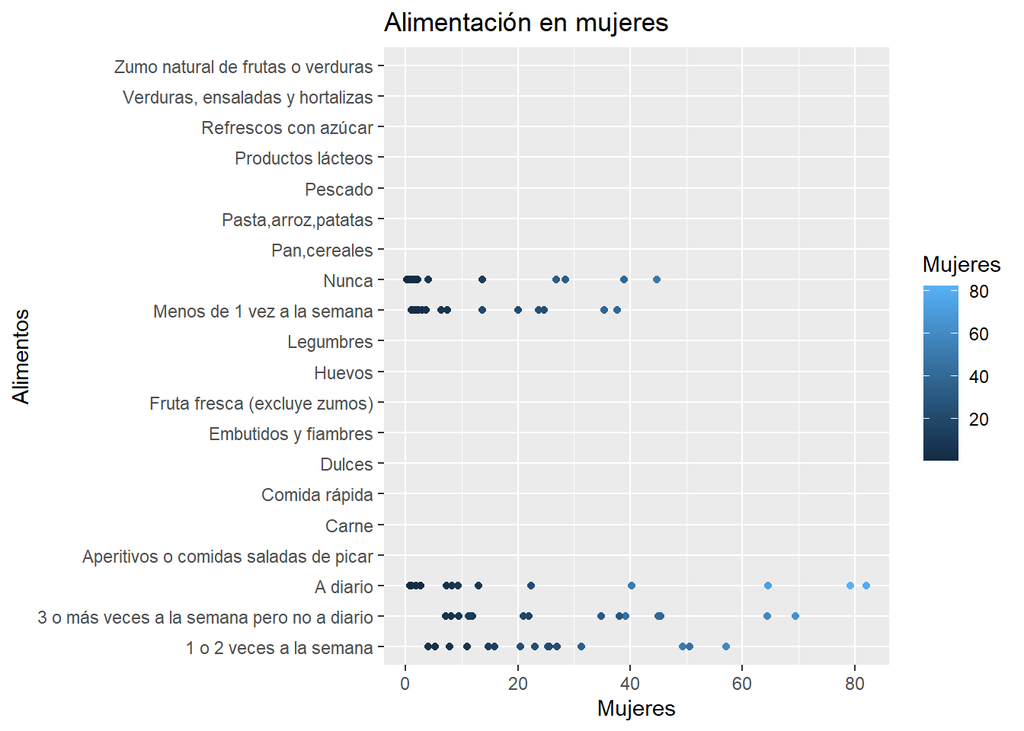

```r
ggplot(data = Comidaxsexoencolumnas) +
  geom_point(mapping = aes( x = Hombres, y= ...1, color= Mujeres)) +
  labs(title = "Alimentación en mujeres", x="Mujeres", y="Alimentos")
```

### Gráfico del paro en relación al sexo

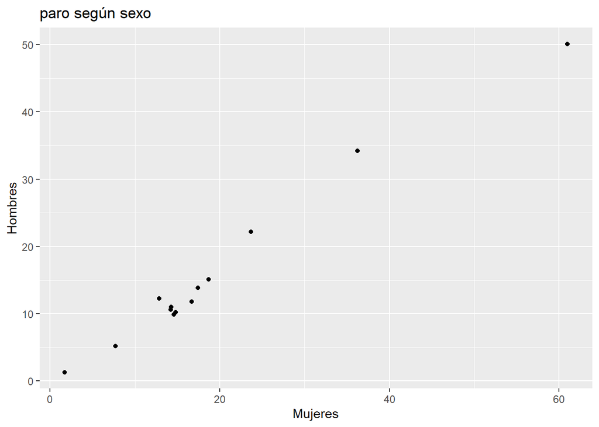

```r
ggplot(data = ParoxsexoEncolumnas) +
  geom_point(mapping = aes( x = Mujeres, y= Hombres))+
  labs(title = "paro según sexo", x="Mujeres", y="Hombres")
```

Debido a esto, hemos decido realizar una separación en dos gráficos, uno para hombres y otro para mujeres. Añadiendo a esta relación el factor de la edad para comprobar si el paro se ve afectado por ella.

### Gráfico del paro en hombres en relación con su edad

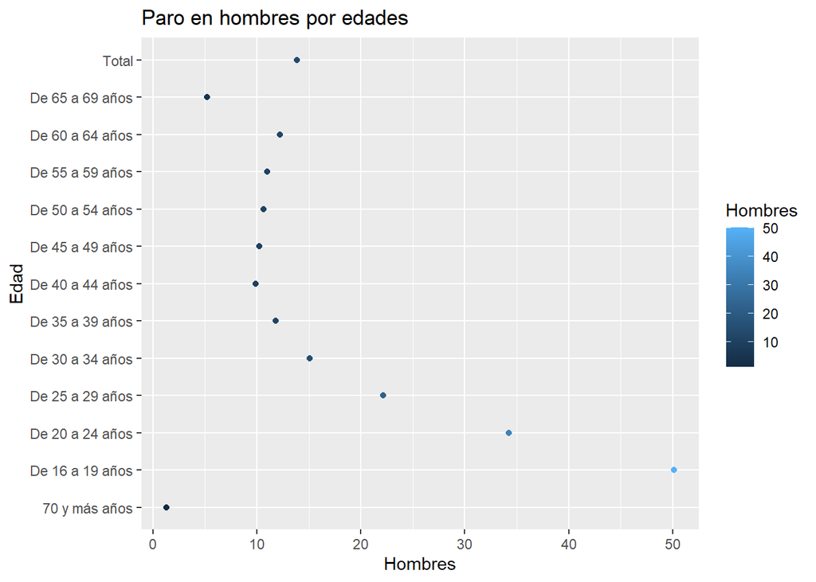

```r
ggplot(data = ParoxsexoEncolumnas) +
  geom_point(mapping = aes( x = Hombres, y= ...1, color= Hombres)) +
  labs(title = "Paro en hombres por edades", x="Hombres", y="Edad")
```

### Gráfico del paro en mujeres en relación a su edad

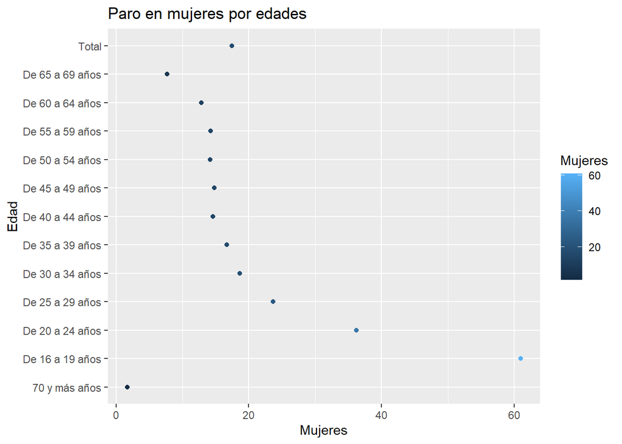

```r
ggplot(data = ParoxsexoEncolumnas) +
  geom_point(mapping = aes( x = Mujeres, y= ...1, color = Mujeres)) +
  labs(title = "Paro en mujeres por edades", x="Mujeres", y="Edad")
```

### Gráfico del paro y la alimentación

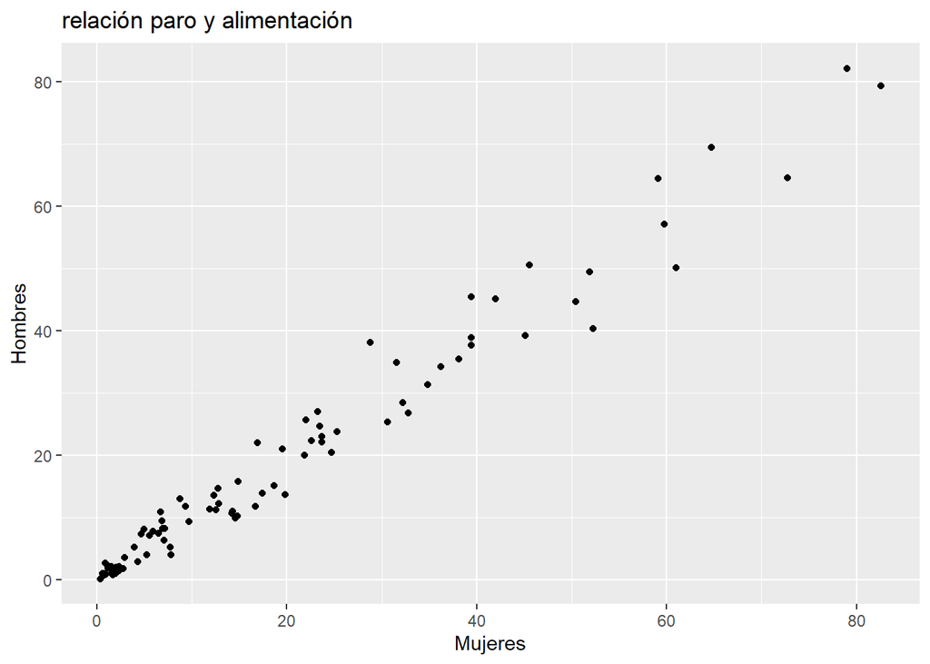

```r
ggplot(data = union) +
  geom_point(mapping = aes( x = Mujeres, y= Hombres)) +
  labs(title="relación paro y alimentación", x="Mujeres", y= "Hombres" )
```

Finalmente, hemos creado un gráfico en el que podemos observar la variación de la alimentación y el paro, tanto en hombres como en mujeres. Además, hemos decidio crear este gráfico de manera indivual para hombres y mujeres, en los cuales relacionamos el paro y la alimentación añadiendo el factor de la edad, pues hemos visto que el paro no se relacionaba con el sexo sino con la edad.

### Gráfico del paro y la alimentación en mujeres según su edad

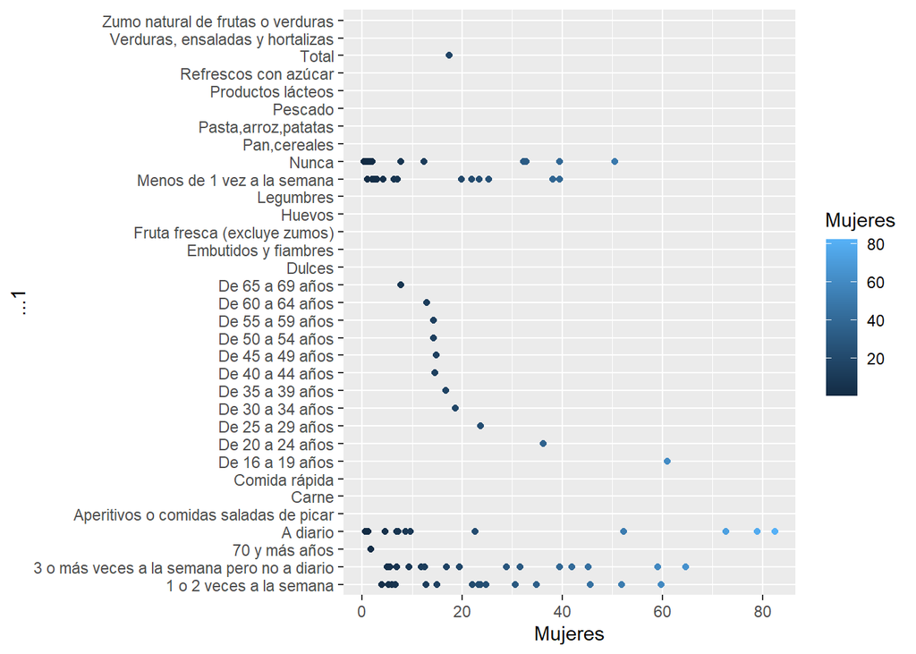

```r
ggplot(data = union) +
  geom_point(mapping = aes( x = Mujeres, y= ...1, color= Mujeres))
```

### Gráfico del paro y la alimentación en hombres según su edad

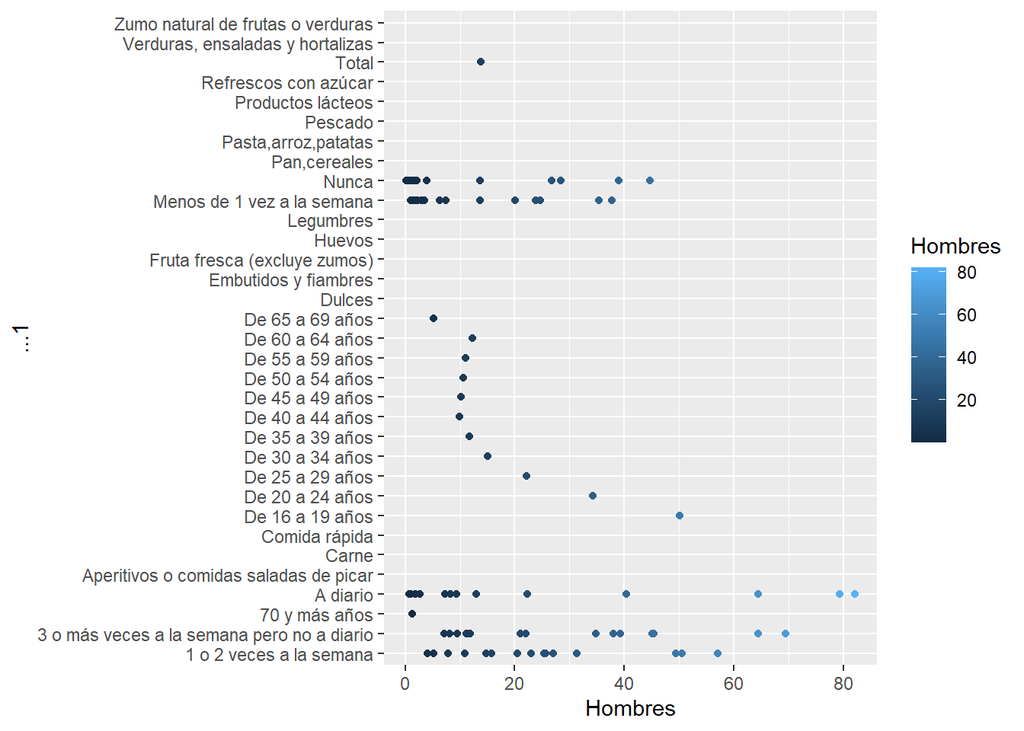

```r
ggplot(data = union) +
  geom_point(mapping = aes( x = Hombres, y= ...1, color= Hombres))
```

# Conclusión

En cuanto a la alimentación, con los resultados obtenidos podemos observar diferencias mínimas entre hombres y mujeres, lo cual indica que la alimentación no está diferenciada por el sexo.

No hemos podido observar una gran diferencia en el paro entre hombres y mujeres, ya que, esta se ve más diferenciada por la edad, es decir, el paro tiene mayor relación con a edad que con el sexo.